# Covid Project Group 13

Adeyinka Telli, Anna Tufail, Daniel McGarvey, Dhvani Patel, Eric Xu, Francesca Bruce, Joshua Brunk, Lauren Brown, Martin Blurton-Jones, Noah Anderson, Ramandeep Singh, Rung-Chian Lo, Suraj Narang

## 0.1 Group 13’s Goals

Our group chose to analyze two different trends in the data from JHU’s Covid Dataset, both trying to evaluate correlation, but one looking at data over time, and the other as a summary to date.

1. For our first hypothesis we wanted to test if major holidays or turning points contributed to a rise in the number of cases of coronavirus in the US.
2. For our second hypothesis we wanted to analyze how a region’s political affiliation impacted an individual’s likelihood to have contracted or been exposed to coronavirus.

# 1 Important Days and Case Increases

Do certain Holiday celebrations line up with increased rates of spread of Covid-19?

First we will create a graph of the new cases each day in the US.

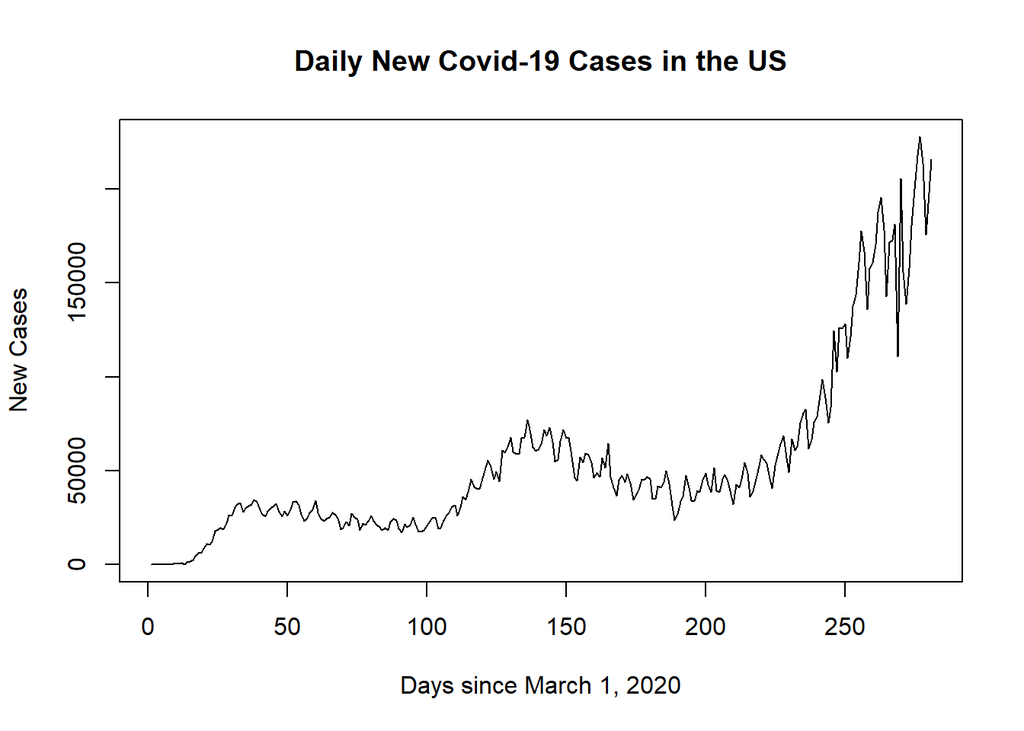

```r
# first get a list of just the total cases each day
cases <- timeline %>% select(seq(12, length(timeline)))
totals <- cases %>% summarize_at(vars(41:length(cases)), sum)
total_list <- data.matrix(totals)

# convert from total cases to new cases
new_cases <- c()
for (i in seq(2, length(total_list))) {
  new_cases <- c(new_cases, (total_list[i] - total_list[i-1]))
}
plot(new_cases, type="l", main="Daily New Covid-19 Cases in the US", xlab = "Days since March 1, 2020", ylab = "New Cases")
```

Now Let’s take a look at the rate of change of this graph to see where the spread sped up and slowed down.

To smooth the plot out, we will measure the rate of change as the difference between the total cases for the seven days after a given date and the total cases for the seven days before this date.

Black points are dates on which the weekly total cases started increasing.

Red lines are labeled with specific holidays.

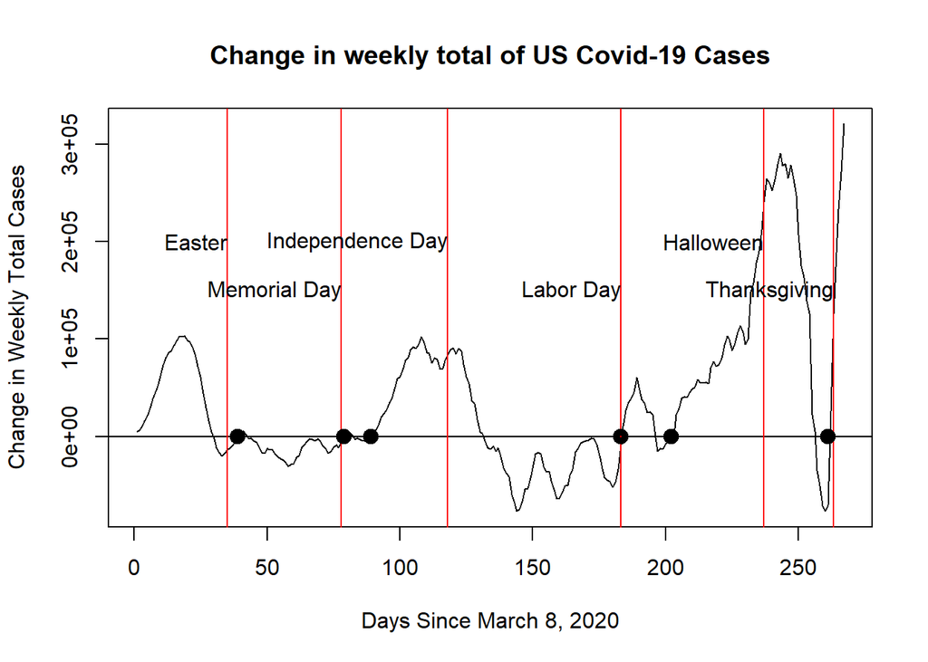

```r
# we can also plot this graph's derivative to see where the number of new cases began increasing
# plotting differences in day to day new cases isn't useful since the rate of change oscillates daily
# let's plot differences between 1 week intervals to see more long term trends
rate_of_change <- c()
for (i in seq(8, length(new_cases) - 7)) {
  rate_of_change <- c(rate_of_change, sum(new_cases[(i):(i+7)]) - sum(new_cases[(i-7):(i)]))
}

# since i started at 8, the new graph starts at March 8 instead of March 1.
start_date <- "2020-03-08"

plot(rate_of_change, type="l", main = "Change in weekly total of US Covid-19 Cases", xlab = "Days Since March 8, 2020", ylab = "Change in Weekly Total Cases")
abline(h=0)

# create A line and label for each holiday
# Halloween, election day, and veterans day all occur in a 2-week time period, so we group them together starting from Halloween
# Note that case numbers following Thanksgiving may not be fully updated by the time of the presentation
holidays <- c("Easter", "Memorial Day", "Independence Day", "Labor Day",  "Halloween", "Thanksgiving")
dates <- c("2020-04-12", "2020-05-25","2020-07-04", "2020-09-07",  "2020-10-31", "2020-11-26")
height <- 200000
for (i in seq(length(dates))) {
  abline(v=as.Date(dates[i])-as.Date(start_date), col="red")
  text(x = as.Date(dates[i])-as.Date(start_date), y = height, holidays[i], adj = c(1, NA))
  # Alternate the heights of the labels
  if (height == 200000) {
    height <- 150000
  } else {
    height <- 200000
  }
}

# find the dates where the rate of change became positive
# need to start off with a date to get started, will remove after loop
zeroes <- as.Date(start_date)
dates <- seq(from=as.Date(start_date), by="day", length.out=length(totals))
for (i in seq(2, length(rate_of_change))) {
  if (rate_of_change[i] > 0 && rate_of_change[i-1] < 0) {
    zeroes <- c(zeroes, dates[i])
  }
}
# remove the starting date
zeroes <- zeroes[2:length(zeroes)]

# plot points for the zeroes
zeroes <- zeroes - as.Date(start_date)
for (z in zeroes) {
  points(z, y=0, lwd = 5)
}
```

Looking at the change in weekly cases, there are a few holidays such as Memorial Day and Labor Day which seem to be followed by an increased rate of spread. However, other days such as Easter and Independence Day saw a minimal change or even a decrease in the rate of spread. Also interesting to note is the dip just before Thanksgiving, which may reflect a change in testing than a change in actual cases. The Holidays do seem to line up with interesting points on the graph, but they are not necessarily the cause of these changes.

# 2 Political Affilitation and Likelihood of Contracting Coronavirus

To evaluate the second hypothesis we took recent polling data from the 2020 election and compared it to the reported cases as well as the population of the county.

First we found a percentage of cases in respect to the population. Then we used the polling data to create a linear model comparing the political affiliation of a region to our normalize cases in respect to the population. Finally we produced a summary of the comparison of cases to political affiliation.

```r
#normalize cases by dividing by the population of each county
combined_data <- transform(combined_data, cases_per_pop = as.integer(Cases) / as.integer(Population))
#put each piece of data into its own variable so it's easier to access
cases_per_pop <- combined_data$cases_per_pop
percent_gop <- combined_data$per_gop
percent_dem <- combined_data$per_dem


gop_vs_cases <- lm(cases_per_pop ~ percent_gop) #use lm to find linear regression for cases_per_pop vs percent_gop
summary(gop_vs_cases) #use this to check p value, degrees of freedom, etc. can determine statistical significance from this.
```

```
##
## Call:
## lm(formula = cases_per_pop ~ percent_gop)
##
## Residuals:
##       Min        1Q    Median        3Q       Max
## -0.042736 -0.015359 -0.002886  0.011498  0.153416
##
## Coefficients:
##             Estimate Std. Error t value Pr(>|t|)
## (Intercept) 0.032004   0.001705   18.77  < 2e-16 ***
## percent_gop 0.012093   0.002540    4.76 2.03e-06 ***
## ---
## Signif. codes:  0 '***' 0.001 '**' 0.01 '*' 0.05 '.' 0.1 ' ' 1
##
## Residual standard error: 0.02244 on 2976 degrees of freedom
##   (2 observations deleted due to missingness)
## Multiple R-squared:  0.007557,   Adjusted R-squared:  0.007223
## F-statistic: 22.66 on 1 and 2976 DF,  p-value: 2.026e-06
```

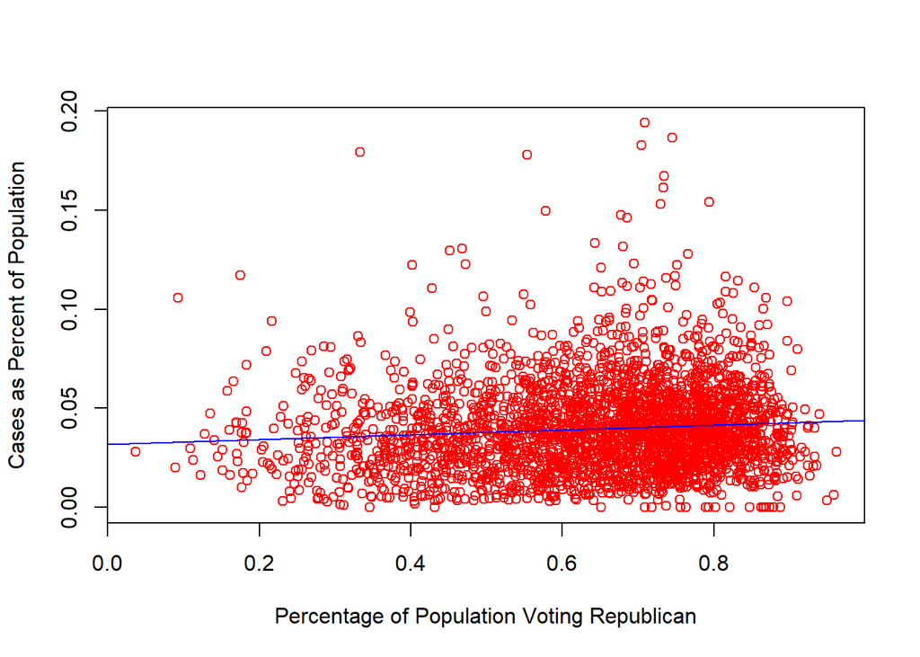

```r
#plot the percentage of cases in each county vs that county's republican leaning
#since normalized cases is in percentage of the population that's had a case, the y axis should be between 0 and 1 (or below 1)
plot(percent_gop, cases_per_pop, col = "red", xlab = "Percentage of Population Voting Republican", ylab = "Cases as Percent of Population")
abline(gop_vs_cases, col ="blue") #mark the linear regression line on the graph
```

```r
dem_vs_cases <- lm(cases_per_pop ~ percent_dem) #use lm to find linear regression for cases_per_pop vs percent_gop
summary(dem_vs_cases) #use this to check p value, degrees of freedom, etc. can determine statistical significance from this.
```

```
##
## Call:
## lm(formula = cases_per_pop ~ percent_dem)
##
## Residuals:
##       Min        1Q    Median        3Q       Max
## -0.042803 -0.015290 -0.002897  0.011433  0.153290
##
## Coefficients:
##               Estimate Std. Error t value Pr(>|t|)
## (Intercept)  0.0440316  0.0009416  46.761   <2e-16 ***
## percent_dem -0.0125453  0.0025597  -4.901    1e-06 ***
## ---
## Signif. codes:  0 '***' 0.001 '**' 0.01 '*' 0.05 '.' 0.1 ' ' 1
##
## Residual standard error: 0.02244 on 2976 degrees of freedom
##   (2 observations deleted due to missingness)
## Multiple R-squared:  0.008007,   Adjusted R-squared:  0.007674
## F-statistic: 24.02 on 1 and 2976 DF,  p-value: 1.004e-06
```

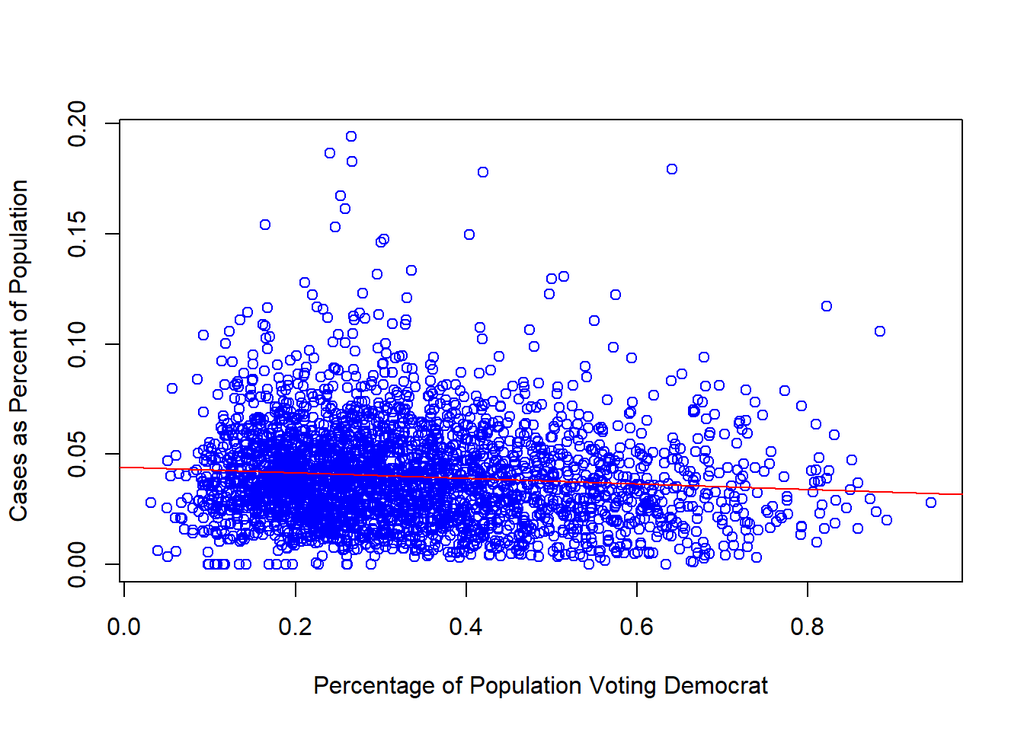

```r
#plot the percentage of cases in each county vs that county's democratic leaning
#since normalized cases is in percentage of the population that's had a case, the y axis should be between 0 and 1 (or below 1)
#this graph should be the reverse of the above graph. just making it to show that it's the reverse, and to mark the correlation between democratic counties vs infection rate as opposed to republican counties vs infection rate
plot(percent_dem, cases_per_pop, col = "blue", xlab = "Percentage of Population Voting Democrat", ylab = "Cases as Percent of Population")
abline(dem_vs_cases, col = "red") #mark the linear regression line on the graph
```

```r
# linear correlation values between percent gop, dem and cases/pop
final = data.frame("cases.pop" = cases_per_pop, "pecent.dem" = percent_dem, "percent.gop" = percent_gop)

cor(final, use = "complete.obs")
```

```
##               cases.pop pecent.dem percent.gop
## cases.pop    1.00000000 -0.0894814  0.08692883
## pecent.dem  -0.08948140  1.0000000 -0.99867748
## percent.gop  0.08692883 -0.9986775  1.00000000
```

Based on the R-squared values, it looks like there is not a strong relationship between these variables. We can confirm from looking at the scatterplot that the majority of data points lie in approximately the same range regardless of party affiliation. However, there is a noticeable number of outliers in proportion of cases for the counties that had a high percentage of Republican voters. These outliers may account for the slight slope in the line of best fit for the scatterplot. There may be other variables besides political affiliation that would account for these extreme cases.

# 3 Sources

- [**JHU’s Covid Data**](https://github.com/CSSEGISandData/COVID-19)
- [**Election Data**](https://github.com/tonmcg/US_County_Level_Election_Results_08-20)
- [**Population Data**](https://www.census.gov/data/tables/time-series/demo/popest/2010s-counties-total.html#par_textimage_242301767)
- [**Project GitHub**](https://github.com/dannymcgarvey/covid-project-group-13)
- [**Our Presentation**](https://docs.google.com/presentation/d/1YDWNrxQ9IbE92SMmyTBhTljRoaz6kIm1GUD9jmRffzk/edit#slide=id.p)